# Лабораторная работа №2

Операционные системы

Мурашов И. В., НКАбд-04-23

Российский университет дружбы народов, Москва, Россия

25 февраля 2024

## Докладчик

- Мурашов Иван Вячеславович
- Cтудент, 1 курс, группа НКАбд-04-23
- Российский университет дружбы народов
- 1132236018@rudn.ru
- https://github.com/neve7mind

## Цель работы

Целью данной лабораторной работы является изучение идеологии, применение средств контроля версий и освоение умений по работе с git.

## Выполнение лабораторной работы

Для начала я устанавливаю git.

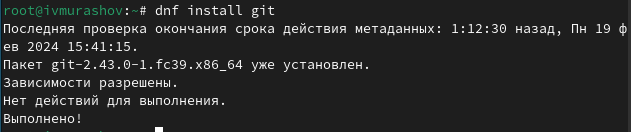

Установка git

## Выполнение лабораторной работы

Затем устанавливаю gh.

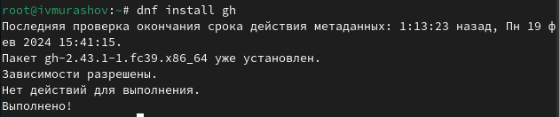

Установка gh

## Выполнение лабораторной работы

Задаю имя и email владельца репозитория.

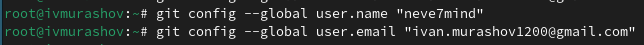

Задание имени и email

## Выполнение лабораторной работы

Настравиваю utf-8 в выводе сообщений git и задаю имя начальной ветки.

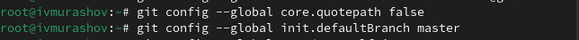

Настройка utf-8

## Выполнение лабораторной работы

Настраиваю параметры autocrlf и safecrlf.

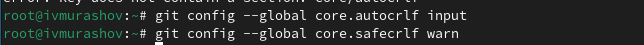

Настройка autocrlf и safecrlf

## Выполнение лабораторной работы

Создаю ключ SSH по алгоритму rsa с ключом размером 4096 бит.

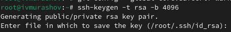

Создание ssh ключа

## Выполнение лабораторной работы

А затем по алгоритму ed25519.

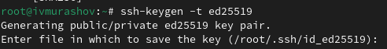

Создание ssh ключа

## Выполнение лабораторной работы

Генерирую ключ PGP, выбирая из предложенных опций тип ‘RSA and RSA’, размер 4096, без срока действия. Указываю имя и адрес email.

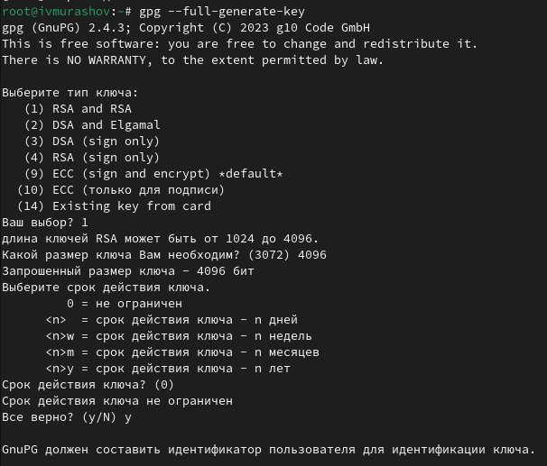

Создание pgp ключа

## Выполнение лабораторной работы

У меня уже был создан профиль на github.

[figure not shown]

Профиль github

## Выполнение лабораторной работы

Вывожу список ключей.

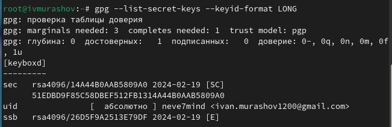

Список ключей

## Выполнение лабораторной работы

Копирую сгенерированный pgp ключ в буфер обмена.

## Выполнение лабораторной работы

Перехожу в настройки GitHub, нажимаю на кнопку ‘New GPG key’ и вставляю скопированный ключ в поле ввода.

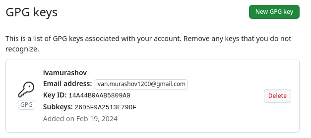

Список ключей

## Выполнение лабораторной работы

Используя введёный email, указываю Git применять его при подписи коммитов.

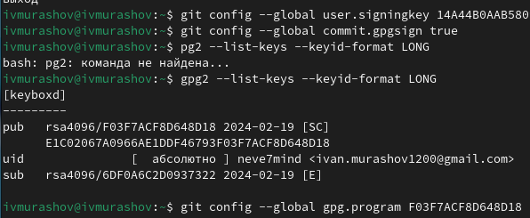

Настройка автоматических подписей

## Выполнение лабораторной работы

Авторизуюсь с помощью браузера (gh login).

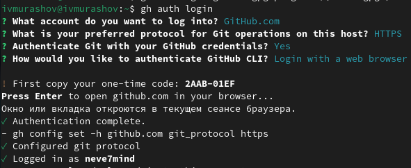

Авторизация

## Выполнение лабораторной работы

Создаю каталог курса, перемещаюсь в него и создаю репозиторий на основе шаблона.

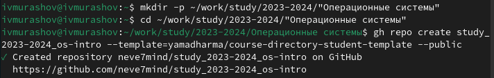

Создание репозитория

## Выполнение лабораторной работы

Клонирую репозиторий.

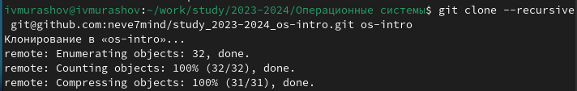

Клонирование репозитория

## Выполнение лабораторной работы

Удаляю лишние файлы, создаю необходимые каталоги.

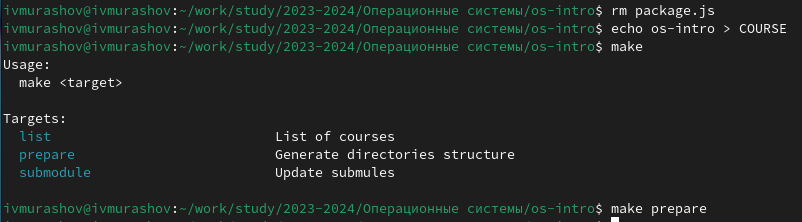

Настройка каталога курса

## Выполнение лабораторной работы

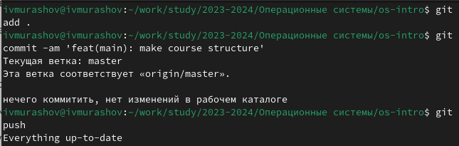

Отправка файлов на сервер

## Выводы

В ходе выполнения данной лабораторной работы я изучил идеологии и применение средств контроля версий и освоил умения по работе с git.